# Pertemuan 3-Teknik Munging/Wrangling

Author

Fitri Diana Musa

Published

September 3, 2026

# A. Recall Materi

1. Vector di R dapat digunakan untuk menyimpan beberapa nilai, dan seluruh elemennya memiliki tipe data yang sama.  
   ☐ Benar ☐ Salah
2. Pada `data.frame`, setiap kolom harus memiliki tipe data yang sama seperti pada matrix.  
   ☐ Benar ☐ Salah
3. Operator `==` digunakan untuk membandingkan dua nilai, sedangkan `<-` dapat digunakan untuk menyimpan nilai ke dalam suatu objek.  
   ☐ Benar ☐ Salah
4. Fungsi `ifelse()` dapat digunakan untuk memberikan hasil yang berbeda pada setiap elemen vector berdasarkan suatu kondisi.  
   ☐ Benar ☐ Salah
5. Perhatikan kode berikut:

   ```
   kode <- "Indonesia Emas 2045"
   substring(kode, first = 7)
   ```

   Apa output yang dihasilkan?
6. Perhatikan kode berikut:

   ```
   kelompok <- c("Ani", "Budi", "Cici")
   rep(kelompok, times = 2)
   ```

   Apa output yang dihasilkan?

# B. Konsep Data Munging/Wrangling

## 1. Apa itu Data Munging?

**Data munging/wrangling** adalah proses **membersihkan, merapikan, dan mengubah data mentah menjadi data yang siap dianalisis**.

Sederhananya:

**Data mentah → Data munging → Data siap dianalisis**

Contoh: kita menerima data mahasiswa, tetapi ada nilai kosong, data ganda, atau angka yang justru terbaca sebagai karakter. Sebelum dianalisis, masalah tersebut perlu dibereskan.

## 2. Data Munging vs Data Cleaning

- **Data Cleaning** → fokus pada **membersihkan kesalahan data**, seperti `NA`, duplikasi, atau format yang salah.
- **Data Munging** → lebih luas. Selain cleaning, juga mencakup **menggabungkan data, mengubah tipe data, dan mengubah struktur data**.

Jadi:

**🗝️Data cleaning adalah salah satu bagian dari data munging.**

## 3. Masalah yang Sering Ada pada Data Mentah

Beberapa masalah umum:

- **Missing value (`NA`)**
- **Data duplikat**
- **Format tidak konsisten**
- **Tipe data tidak sesuai**

**Garbage in, garbage out — kalau data yang masuk bermasalah, hasil analisisnya juga bisa bermasalah.**

# C. Eksplorasi Awal dan Membaca Data

Sebelum data dibersihkan atau dimanipulasi, kita perlu **membaca dan mengenali struktur datanya terlebih dahulu**.

## 1. Membaca Data ke R

Berbagai cara membaca data ke R:

| Tipe File | Package/Fungsi | Contoh Kode |
| --- | --- | --- |
| **CSV (.csv)** | Base R | `data <- read.csv("data.csv")` |
| **CSV (.csv)** | `readr` | `data <- read_csv("data.csv")` |
| **Excel (.xlsx/.xls)** | `readxl` | `data <- read_excel("data.xlsx")` |
| **Excel — sheet tertentu** | `readxl` | `data <- read_excel("data.xlsx", sheet = "Sheet1")` |
| **TXT (.txt)** | Base R | `data <- read.table("data.txt", header = TRUE)` |
| **TXT dipisah tab** | Base R | `data <- read.table("data.txt", header = TRUE, sep = "\t")` |
| **TSV (.tsv)** | Base R | `data <- read.delim("data.tsv")` |
| **TSV (.tsv)** | `readr` | `data <- read_tsv("data.tsv")` |
| **Word (.docx)** | `officer` | `dokumen <- read_docx("dokumen.docx")` |
| **PDF (.pdf)** | `pdftools` | `teks <- pdf_text("dokumen.pdf")` |
| **SPSS (.sav)** | `haven` | `data <- read_sav("data.sav")` |
| **Stata (.dta)** | `haven` | `data <- read_dta("data.dta")` |
| **SAS (.sas7bdat)** | `haven` | `data <- read_sas("data.sas7bdat")` |
| **JSON (.json)** | `jsonlite` | `data <- fromJSON("data.json")` |
| **RDS (.rds)** | Base R | `data <- readRDS("data.rds")` |
| **RData (.RData)** | Base R | `load("data.RData")` |

Bagaimana jika kita tidak tau file path nya?

Kode yang bisa digunakan yaitu:

```
file.choose()
```

| File | Contoh |
| --- | --- |
| CSV | `data <- read.csv(file.choose())` |
| Excel | `data <- read_excel(file.choose())` |
| PDF | `teks <- pdf_text(file.choose())` |

**file.choose() akan membuka File Explorer, sehingga kita tinggal memilih file secara manual.**

Berikut beberapa cara penulisan file path di Windows:

| Cara | Contoh |
| --- | --- |
| Gunakan `/` | `"C:/Users/user/Downloads/data.csv"` |
| Gunakan `\\` | `"C:\\Users\\user\\Downloads\\data.csv"` |

## 2. Eksplorasi Awal Data

Beberapa fungsi penting yaitu:

| Fungsi | Kegunaan |
| --- | --- |
| `head(dataku)` | Menampilkan **6 baris pertama** data |
| `tail(dataku)` | Menampilkan **6 baris terakhir** data |
| `str(dataku)` | Melihat **struktur data dan tipe data** setiap variabel |
| `summary(dataku)` | Menampilkan **ringkasan statistik** setiap variabel |
| `names(dataku)` | Menampilkan **nama-nama kolom** |
| `dim(dataku)` | Menampilkan **jumlah baris dan kolom** |

## 3. Indexing Dasar

Beberapa kode R yang dapat digunakan untuk indexing yaitu:

| Kode | Kegunaan |
| --- | --- |
| `dataku[baris, kolom]` | Format umum untuk mengakses data berdasarkan baris dan kolom |
| `dataku[1, ]` | Mengambil **baris pertama** |
| `dataku[, 1]` | Mengambil **kolom pertama** |
| `dataku[1, 2]` | Mengambil nilai pada **baris 1, kolom 2** |
| `dataku$Nama` | Mengambil kolom bernama **Nama** |
| `dataku[, "Umur"]` | Mengambil kolom bernama **Umur** |

# D. Teknik Pembersihan Data (Data Cleaning)

## 1. Menangani Missing Value (NA)

Prinsipnya:

**Deteksi dulu → kemudian tentukan cara menanganinya.**

| Kode | Kegunaan |
| --- | --- |
| `is.na(dataku)` | Mengecek posisi `NA`, menghasilkan `TRUE/FALSE` |
| `sum(is.na(dataku))` | Menghitung jumlah seluruh `NA` |
| `na.omit(dataku)` | Menghapus baris yang memiliki `NA` |
| `mean(x, na.rm = TRUE)` | Menghitung rata-rata dengan mengabaikan `NA` |

## 2. Membersihkan Format dan Konversi Tipe Data

Bagian ini digunakan ketika **format data tidak seragam** atau **tipe datanya tidak sesuai**. Misalnya angka terbaca sebagai karakter, atau penulisan nama memiliki spasi berlebih.

### 2.1 Konversi Tipe Data

Beberapa fungsi yang dapat digunakan untuk mengonversi tipe data yaitu:

| Fungsi | Kegunaan |
| --- | --- |
| `as.numeric()` | Mengubah data menjadi numerik |
| `as.character()` | Mengubah data menjadi karakter |
| `as.factor()` | Mengubah data menjadi faktor/kategori |
| `as.Date()` | Mengubah data menjadi format tanggal |

### 2.2 Pembersihan Teks

Beberapa fungsi di R yang dapat digunakan untuk pembersihan teks yaitu:

| Fungsi | Kegunaan |
| --- | --- |
| `tolower()` | Mengubah semua teks menjadi huruf kecil |
| `toupper()` | Mengubah semua teks menjadi huruf besar |
| `trimws()` | Menghapus spasi di awal dan akhir teks |
| `gsub()` | Mengganti pola tertentu pada teks |

Misalnya, pada data yang kita gunakan terdapat **spasi berlebih di antara karakter atau kata**, kita dapat menggunakan fungsi `gsub()` untuk membersihkannya.

`gsub()` merupakan singkatan dari **global substitution**, yaitu fungsi yang digunakan untuk **mencari pola tertentu pada teks dan menggantinya dengan pola lain secara menyeluruh**.

Misalnya:

```r
dataku <- data.frame(
  Nama = c("Andi  Saputra", "Budi   Santoso", "Citra Dewi"),
  Umur = c(21, 22, 20),
  Nilai = c(85, 90, 78)
)
```

Perhatikan ada nama yang memiliki **dua atau tiga spasi** di tengah.

Lalu jalankan kode berikut:

```r
dataku$Nama <- gsub("[ ]+", " ", dataku$Nama)
dataku
```

```
          Nama Umur Nilai
1 Andi Saputra   21    85
2 Budi Santoso   22    90
3   Citra Dewi   20    78
```

Hasilnya:

```
[1] "Andi Saputra"  "Budi Santoso"  "Citra Dewi"
```

Cara kode tersebut dibaca oleh R adalah:

- `[ ]` → mencari karakter spasi
- `+` → satu atau lebih spasi
- `" "` → diganti menjadi **satu spasi**

Lalu, bisa tidak gsub() ini digunakan untuk fungsi lain? Misalnya menghapus tanda titik, mengganti tanda dsb?

Jawabannya, bisa, sangat bisa.  
Karena `gsub()` tidak hanya untuk menghapus spasi berlebih. Fungsinya lebih umum: **mencari pola tertentu pada teks lalu menggantinya dengan pola lain**.

Contohnya:

| Masalah | Kode | Hasil |
| --- | --- | --- |
| Menghapus spasi berlebih | `gsub("[ ]+", " ", "Budi Santoso")` | `"Budi Santoso"` |
| Menghapus tanda titik | `gsub("\\.", "", "A.B.C")` | `"ABC"` |
| Mengganti tanda `-` menjadi `/` | `gsub("-", "/", "2026-09-03")` | `"2026/09/03"` |
| Menghapus angka dari teks | `gsub("[0-9]", "", "Kelas123")` | `"Kelas"` |
| Menghapus simbol tertentu | `gsub("[@#]", "", "data@2026#")` | `"data2026"` |
| Mengganti kata tertentu | `gsub("pria", "laki-laki", "pria dewasa")` | `"laki-laki dewasa"` |

**gsub() itu fleksibel. Selama kita bisa menentukan pola teks yang ingin dicari, pola itu bisa dihapus atau diganti dengan pola lain.**

## 3. Mengatasi Duplikasi Data

Data duplikat adalah **baris pengamatan yang tercatat lebih dari satu kali**.

Fungsi yang digunakan:

| Kode | Kegunaan |
| --- | --- |
| `duplicated(dataku)` | Mengecek baris duplikat, menghasilkan `TRUE/FALSE` |
| `dataku[duplicated(dataku), ]` | Menampilkan baris yang duplikat |
| `dataku[!duplicated(dataku), ]` | Menyimpan hanya baris yang unik |
| `unique(dataku)` | Cara singkat untuk mengambil baris unik |

Contoh:

```r
dataku <- data.frame(
  Nama = c("Andi", "Budi", "Andi"),
  Nilai = c(80, 90, 80)
)
```

Mendeteksi Duplikat:

```r
duplicated(dataku)
```

```
[1] FALSE FALSE  TRUE
```

Artinya, **baris ketiga merupakan duplikat dari baris sebelumnya**.

Menghapus duplikat:

```r
data_unik <- unique(dataku)
data_unik
```

```
  Nama Nilai
1 Andi    80
2 Budi    90
```

## 4. Mendeteksi dan Menangani Outlier

**Outlier atau pencilan** adalah pengamatan yang nilainya jauh berbeda dibandingkan sebagian besar data lainnya.

Outlier dapat diperiksa menggunakan **boxplot dan metode IQR**.

### 4.1 Melihat Outlier dengan Boxplot

```r
dataku <- data.frame(
  Nama = c("Andi", "Budi", "Citra", "Dewi", "Eka", "Fajar", "Gita"),
  Umur = c(21, 20, 22, 21, 23, 20, 35)
)

dataku
```

```
   Nama Umur
1  Andi   21
2  Budi   20
3 Citra   22
4  Dewi   21
5   Eka   23
6 Fajar   20
7  Gita   35
```

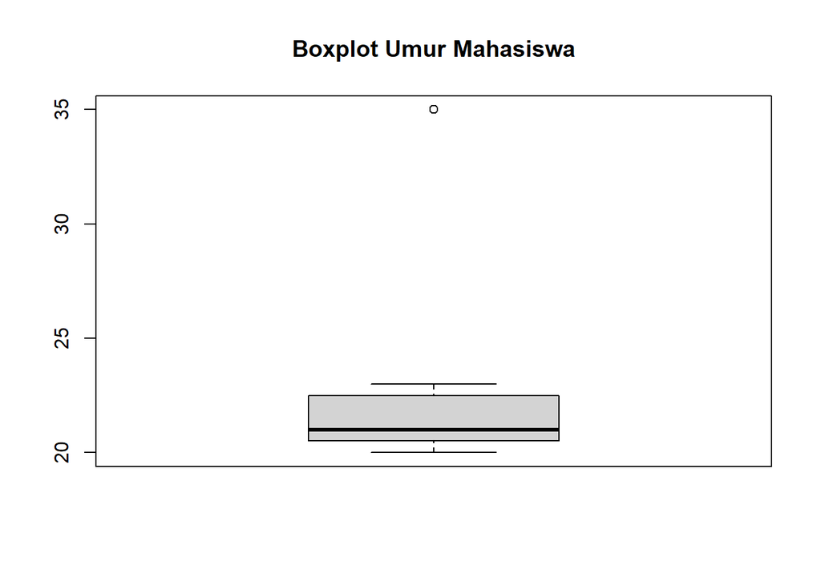

```r
boxplot(dataku$Umur,
        main = "Boxplot Umur Mahasiswa")
```

Titik yang berada di luar whisker boxplot dapat menjadi **indikasi outlier**.

### 4.2 Menggunakan IQR

**IQR (Interquartile Range)** adalah ukuran yang menunjukkan **sebaran 50% data yang berada di bagian tengah**.

Rumusnya:

$$IQR=Q3−Q1$$

dengan:

- **Q1** = kuartil pertama, yaitu nilai yang membatasi 25% data terbawah
- **Q3** = kuartil ketiga, yaitu nilai yang membatasi 75% data

Jadi, IQR mengukur jarak antara **Q1 dan Q3**.

**Bagaimana IQR dipakai untuk mendeteksi outlier?**

Batas yang digunakan adalah:

Batas Bawah = Q1 − 1.5 × IQR

Batas Atas = Q3 + 1.5 × IQR

Nilai yang berada:

- di bawah batas bawah, atau
- di atas batas atas

akan dianggap sebagai **calon outlier**.

Contoh:

```r
# Batas Outlier
Q1 <- quantile(dataku$Umur, 0.25)
Q3 <- quantile(dataku$Umur, 0.75)

IQR_val <- Q3 - Q1
```

Kemudian menyaring data sesuai dengan batas outlier:

```r
data_clean <- dataku[
  dataku$Umur >= (Q1 - 1.5 * IQR_val) &
    dataku$Umur <= (Q3 + 1.5 * IQR_val),
]
data_clean
```

```
   Nama Umur
1  Andi   21
2  Budi   20
3 Citra   22
4  Dewi   21
5   Eka   23
6 Fajar   20
```

# E. Teknik Munging dalam Data Frame

Kalau pada bagian sebelumnya kita fokus membersihkan data, pada bagian ini kita mulai membentuk dan menyusun data sesuai kebutuhan analisis. Jadi, data yang sudah bersih belum tentu langsung siap dipakai; kadang masih perlu disaring, digabung, diurutkan, atau diubah bentuknya.

## 1. Menambahkan Kolom/Peubah Baru

Kolom baru dapat dibuat dari **hasil operasi kolom yang sudah ada**.

Contoh:

```r
dtku <- data.frame(
  Nama = c("Andi", "Budi", "Citra"),
  Matematika = c(80, 90, 75),
  Statistika = c(85, 88, 78)
)
dtku
```

```
   Nama Matematika Statistika
1  Andi         80         85
2  Budi         90         88
3 Citra         75         78
```

Tambahkan kolom baru:

```r
dtku$Total <- dtku$Matematika + dtku$Statistika
dtku
```

```
   Nama Matematika Statistika Total
1  Andi         80         85   165
2  Budi         90         88   178
3 Citra         75         78   153
```

Bisa juga membuat rata-rata:

```r
dtku$Rata_rata <- (dtku$Matematika + dtku$Statistika) / 2
dtku
```

```
   Nama Matematika Statistika Total Rata_rata
1  Andi         80         85   165      82.5
2  Budi         90         88   178      89.0
3 Citra         75         78   153      76.5
```

## 2. Subsetting Data

**Subsetting** adalah teknik untuk **memilih atau menyaring sebagian data** berdasarkan kondisi tertentu.

Contoh:

```r
a <- data.frame(
  gender = c("f", "f", "m", "m"),
  u = c(18, 19, 18, 20),
  n = c(81, 76, 88, 89)
)
a
```

```
  gender  u  n
1      f 18 81
2      f 19 76
3      m 18 88
4      m 20 89
```

Jika ingin memilih gender perempuan:

```r
idx_f <- a$gender == "f"
data_female <- a[idx_f, ]
idx_f
```

```
[1]  TRUE  TRUE FALSE FALSE
```

```r
# data_female
```

Artinya: pilih baris dengan `gender == "f"`.

Operator yang sering digunakan:

[output not shown]

**Subsetting digunakan ketika kita tidak ingin memakai seluruh data, tetapi hanya pengamatan yang memenuhi syarat tertentu.**

Bagaimana jika ingin **hanya mahasiswa laki-laki**, **nilai di atas 80?**

## 3. Mengurutkan Data (Sorting)

Sorting digunakan untuk **mengurutkan baris data berdasarkan nilai pada satu atau beberapa kolom**. Pada R Base, fungsi utamanya adalah `order()`.

Contoh:

```r
a <- data.frame(
  gender = c("f", "f", "m", "m"),
  u = c(18, 19, 18, 20),
  n = c(81, 76, 88, 89)
)
```

**Mengurutkan berdasarkan nilai `n` :**

- Ascending : kecil → besar

```r
a[order(a$n), ]
```

```
  gender  u  n
2      f 19 76
1      f 18 81
3      m 18 88
4      m 20 89
```

- Descending : besar → kecil

```r
a[order(a$n, decreasing = TRUE), ]
```

```
  gender  u  n
4      m 20 89
3      m 18 88
1      f 18 81
2      f 19 76
```

- Sorting dengan Lebih dari Satu Kriteria

Misalnya:

Urutkan berdasarkan `gender` lalu jika gender sama, urutkan berdasarkan `n`.

```r
a[order(a$gender, a$n), ]
```

```
  gender  u  n
2      f 19 76
1      f 18 81
3      m 18 88
4      m 20 89
```

## 4. Mengkode Ulang Data (*Recoding*)

**Recoding** adalah mengubah nilai suatu variabel menjadi **kategori atau kode baru berdasarkan aturan tertentu**.

### 4.1 Cara Manual dengan Operasi Logika

Contoh:

```r
a <- data.frame(
  nama = c("Andi", "Budi", "Citra", "Dewi", "Eko"),
  gender = c("m", "m", "f", "f", "m"),
  u = c(18, 19, 18, 20, 21),
  n = c(81, 76, 88, 89, 92)
)
a
```

```
   nama gender  u  n
1  Andi      m 18 81
2  Budi      m 19 76
3 Citra      f 18 88
4  Dewi      f 20 89
5   Eko      m 21 92
```

Misalnya:

- umur ≤ 18 → kode `1`
- umur > 18 → kode `2`

```r
a$grup_umur <- 1 * (a$u <= 18) +
  2 * (a$u > 18)
a
```

```
   nama gender  u  n grup_umur
1  Andi      m 18 81         1
2  Budi      m 19 76         2
3 Citra      f 18 88         1
4  Dewi      f 20 89         2
5   Eko      m 21 92         2
```

### 4.2 Menggunakan `ifelse()`

```r
a$grup_umur2 <- ifelse(
  a$u <= 18,
  "Remaja",
  "Dewasa"
)
a
```

```
   nama gender  u  n grup_umur grup_umur2
1  Andi      m 18 81         1     Remaja
2  Budi      m 19 76         2     Dewasa
3 Citra      f 18 88         1     Remaja
4  Dewi      f 20 89         2     Dewasa
5   Eko      m 21 92         2     Dewasa
```

### 4.3 Fungsi lain yang Bisa Digunakan

| Fungsi | Cocok digunakan ketika |
| --- | --- |
| `cut()` | Membagi angka menjadi beberapa interval/kategori |
| `dplyr::case_when()` | Memiliki banyak kondisi |
| `switch()` | Memilih hasil berdasarkan nilai tertentu |

Contoh:

```r
# Contoh case_when()
library(dplyr)
a$status_nilai <- case_when(
  a$n >= 90 ~ "A",
  a$n >= 80 ~ "B",
  a$n >= 70 ~ "C",
  TRUE ~ "D"
)
a
```

```
   nama gender  u  n grup_umur grup_umur2 status_nilai
1  Andi      m 18 81         1     Remaja            B
2  Budi      m 19 76         2     Dewasa            C
3 Citra      f 18 88         1     Remaja            B
4  Dewi      f 20 89         2     Dewasa            B
5   Eko      m 21 92         2     Dewasa            A
```

## 5. Menggabungkan Data Frame

**Join** digunakan untuk **menggabungkan dua atau lebih data frame**.

Fungsi yang dapat digunakan:

| Fungsi | Kegunaan |
| --- | --- |
| `cbind()` | Menggabungkan **kolom** secara berdampingan |
| `rbind()` | Menggabungkan **baris** secara vertikal |
| `merge()` | Menggabungkan data berdasarkan **kolom kunci / ID** |

Contoh:

- Menggabungkan Data Frame dengan Fungsi rbind():

```r
a3 <- data.frame(
  id = c("A.0", "B.1", "C.0"),
  gender = c("f", "f", "f"),
  v1 = c(10, 15, 8)
)

a4 <- data.frame(
  id = c("D.1", "E.1", "F.0"),
  gender = c("m", "m", "f"),
  v1 = c(12, 9, 11)
)

# Menggabungkan Data Frame dengan Fungsi rbind()
gabung_baris <- rbind(a3, a4)
gabung_baris
```

```
   id gender v1
1 A.0      f 10
2 B.1      f 15
3 C.0      f  8
4 D.1      m 12
5 E.1      m  9
6 F.0      f 11
```

- Menggabungkan Data Frame dengan Fungsi merge():

```r
# Data Frame
df1 <- data.frame(ID=c(1,2,3), x=c(10,20,30))
df2 <- data.frame(ID=c(2,3,4), y=c(200,300,400))

# Inner join
merge(df1, df2, by="ID")
```

```
  ID  x   y
1  2 20 200
2  3 30 300
```

```r
# Left join
merge(df1, df2, by="ID", all.x=TRUE)
```

```
  ID  x   y
1  1 10  NA
2  2 20 200
3  3 30 300
```

```r
# Full join
merge(df1, df2, by="ID", all=TRUE)
```

```
  ID  x   y
1  1 10  NA
2  2 20 200
3  3 30 300
4  4 NA 400
```

## 6. Mengubah Format Data Frame (*Reshape: Wide ↔︎ Long*)

**Reshape** adalah proses **mengubah bentuk struktur data**. **Wide** dan **long** adalah dua bentuk penyusunan data.

Contoh format **wide**:

| ID | Skor1 | Skor2 |
| --- | --- | --- |
| A | 80 | 85 |
| B | 75 | 90 |

Satu subjek berada dalam **satu baris**, sedangkan pengukuran berada di beberapa kolom.

Contoh format **long**:

| ID | Variabel | Skor |
| --- | --- | --- |
| A | Skor1 | 80 |
| A | Skor2 | 85 |
| B | Skor1 | 75 |
| B | Skor2 | 90 |

Satu subjek dapat muncul dalam **beberapa baris**.

**Contoh Wide → Long:**

```r
wide_data <- data.frame(
  ID = c("T1", "T2", "T3"),
  Minggu1 = c(120, 150, 95),
  Minggu2 = c(135, 140, 110)
)

wide_data
```

```
  ID Minggu1 Minggu2
1 T1     120     135
2 T2     150     140
3 T3      95     110
```

Ubah menjadi **long**:

```r
long_data <- reshape(
  wide_data,
  varying = c("Minggu1", "Minggu2"),
  v.names = "Penjualan",
  timevar = "Waktu",
  times = c("Minggu1", "Minggu2"),
  idvar = "ID",
  direction = "long"
)

long_data
```

```
           ID   Waktu Penjualan
T1.Minggu1 T1 Minggu1       120
T2.Minggu1 T2 Minggu1       150
T3.Minggu1 T3 Minggu1        95
T1.Minggu2 T1 Minggu2       135
T2.Minggu2 T2 Minggu2       140
T3.Minggu2 T3 Minggu2       110
```

**Contoh Long → Wide:**

Dari `long_data` tadi, kita kembalikan ke bentuk wide:

```r
wide_data_back <- reshape(
  long_data,
  idvar = "ID",
  timevar = "Waktu",
  direction = "wide"
)

wide_data_back
```

```
           ID Penjualan.Minggu1 Penjualan.Minggu2
T1.Minggu1 T1               120               135
T2.Minggu1 T2               150               140
T3.Minggu1 T3                95               110
```

**Tulisan T1.Minggu1 di sebelah kiri bukan variabel atau kolom data, tetapi hanya nama baris yang otomatis dibuat oleh reshape().**

Kalau tidak ingin nama baris tersebut muncul, setelah `reshape()` jalankan:

```
rownames(long_data) <- NULL
```

```r
long_data <- reshape(
  wide_data,
  varying = c("Minggu1", "Minggu2"),
  v.names = "Penjualan",
  timevar = "Waktu",
  times = c("Minggu1", "Minggu2"),
  idvar = "ID",
  direction = "long"
)
rownames(long_data) <- NULL

long_data
```

```
  ID   Waktu Penjualan
1 T1 Minggu1       120
2 T2 Minggu1       150
3 T3 Minggu1        95
4 T1 Minggu2       135
5 T2 Minggu2       140
6 T3 Minggu2       110
```

# F. Latihan Soal

1. Buatlah sebuah data frame bernama `df` dengan 2 kolom: `A = c("X1","X2","X3","X4")` dan `nilai = c(10,15,20,25)`. Tambahkan kolom baru `nilai2` yang berisi `nilai` dikali 2.
2. Dari data frame `df`, ambil baris yang memiliki `nilai > 15`.
3. Urutkan data frame `df` berdasarkan kolom `nilai` secara menurun.
4. Gunakan `ifelse()` untuk membuat kolom baru `kategori`, dengan aturan:
   - `nilai >= 20` → `"Tinggi"`
   - selain itu → `"Rendah"`
5. Gunakan fungsi `recode()` dari package `car` untuk mengubah variabel `nilai` menjadi:
   - `10:15 = "A"`
   - `20:25 = "B"`
6. Buat data frame kedua `df2` dengan isi:

   A = c(“X2”,“X4”), keterangan = c(“Lulus”,“Gagal”)

   Gabungkan `df` dan `df2` berdasarkan kolom `A` sehingga setiap `A` memiliki keterangan (NA jika tidak ada).
7. Ubah data frame berikut dari long ke wide format:

   ```r
   data_long <- data.frame(
     ID = c(1,1,2,2),
     waktu = c("T1","T2","T1","T2"),
     skor = c(80,90,70,75)
   )
   ```

8. Ubah data frame hasil dari Soal 7 kembali menjadi long format.
9. Diberikan data frame:

   ```r
   set.seed(123)
   df3 <- data.frame(
     Grup = rep(c("A","B"), each=4),
     Nilai = sample(1:10, 8)
   )
   ```

   - Urutkan berdasarkan `Grup` lalu `Nilai` menurun.
   - Buat kolom `Status` dengan aturan: Nilai > 5 = `"Baik"`, lainnya = `"Kurang"`.
10. Jika terdapat data frame berikut:

    ```r
    df4 <- data.frame(
      Kelas = rep(c("K1","K2","K3"), each=2),
      Siswa = paste0("S",1:6),
      Nilai = c(80,70,65,90,85,60)
    )
    ```

    - Ubah ke format wide dengan `Kelas` sebagai kolom dan `Siswa` sebagai baris.
    - Dari hasil wide tersebut, ubah kembali ke format long.
    - Tambahkan kolom `Lulus` dengan aturan: `Nilai >= 75` = 1, lainnya = 0.